# Regression Analysis in R: A Complete Guide for Undergraduate Students

Linear Regression, Multiple Regression, LDA, and Other Regression Techniques

Dr. Ankit Deshmukh

2026-09-10

# Introduction to Regression Analysis

## What is Regression?

**Regression analysis** is one of the most fundamental and widely used statistical techniques in data science, machine learning, and scientific research. At its core, regression helps us understand **relationships between variables** and make **predictions** based on those relationships.

**Formal Definition**: Regression is a statistical method for estimating the relationships between a dependent variable (often called the **response** or **outcome**) and one or more independent variables (called **predictors**, **features**, or **explanatory variables**).

### The Story of Regression

The term “regression” was coined by **Sir Francis Galton** in the 19th century. While studying the heights of parents and their children, Galton observed that children’s heights tended to “regress” toward the average height of the population. This phenomenon, called **regression toward the mean**, gave birth to the statistical technique we use today.

### Why Do We Need Regression?

Imagine you are a botanist studying iris flowers. You might ask:

- *“Can I predict the petal length of an iris flower based on its sepal length?”*
- *“How do multiple measurements together help classify iris species?”*
- *“What is the relationship between different flower parts?”*

Regression helps answer these questions quantitatively. It allows us to:

1. **Predict** unknown values based on known information
2. **Explain** how changes in one variable affect another
3. **Control** for confounding variables
4. **Classify** observations into categories (via logistic regression or LDA)

# Understanding the Iris Dataset

## The Iris Flower: Botanical Background

Before diving into regression, let’s understand our dataset. The **Iris dataset** is perhaps the most famous dataset in statistics and machine learning, introduced by **Sir Ronald A. Fisher** in his 1936 paper on discriminant analysis.

The dataset contains measurements of **150 iris flowers** from three species: - **Iris setosa** (50 flowers) - **Iris versicolor** (50 flowers) - **Iris virginica** (50 flowers)

### Sepal vs. Petal: What’s the Difference?

Understanding flower anatomy is crucial for understanding this dataset:

| Term | Description | Function |
| --- | --- | --- |
| **Sepal** | The outer, leaf-like protective structures of a flower bud | Protect the flower before it blooms; often green and photosynthetic |
| **Petal** | The inner, often colorful structures of a flower | Attract pollinators with color and scent |

In the iris flower: - **Sepals** are the three outer segments that hang downward (called “falls” in iris terminology) - **Petals** are the three inner segments that stand upright (called “standards”)

### Visual Reference: The Iris Flower

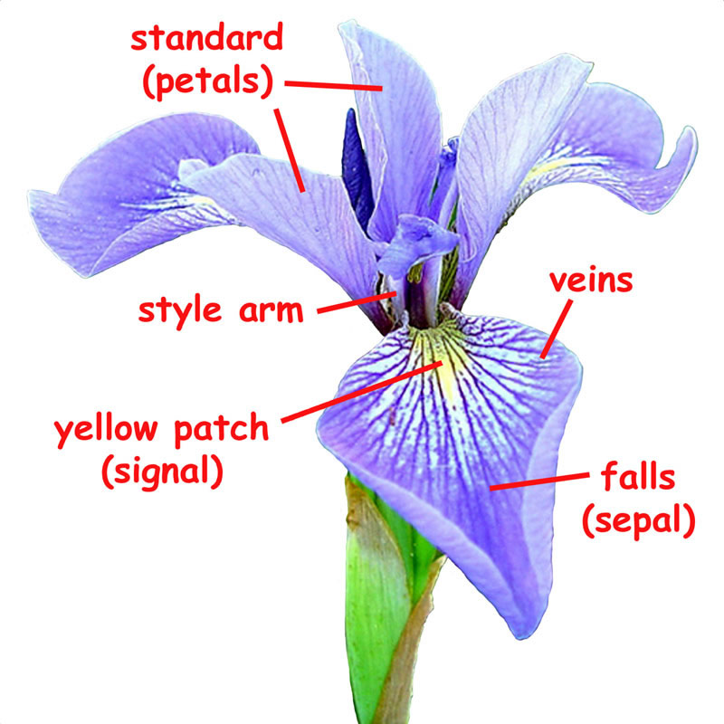

Labeled Iris Flower Anatomy

*Figure 1: Anatomy of an iris flower showing petals (standards) and sepals (falls). Source: USDA Forest Service.*

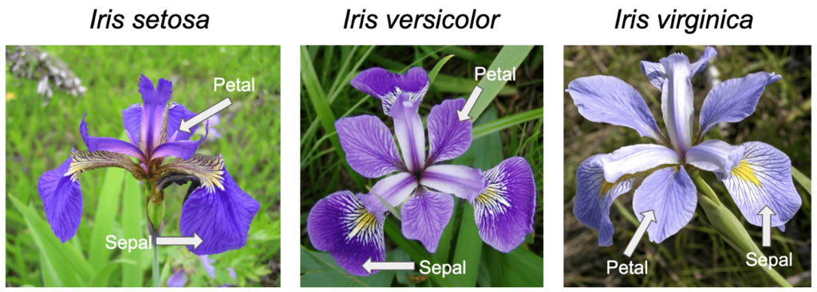

Three Iris Species Comparison

*Figure 2: The three iris species in our dataset. Notice the differences in petal and sepal sizes. Source: GitHub educational repository.*

## The Four Measurements

For each flower, four measurements were recorded (in centimeters):

1. **Sepal.Length** – Length of the sepal
2. **Sepal.Width** – Width of the sepal
3. **Petal.Length** – Length of the petal
4. **Petal.Width** – Width of the petal

## Loading and Exploring the Data

```r
# Load the iris dataset (built into R)
data(iris)

# View the first few rows
head(iris, 10)
```

```
##    Sepal.Length Sepal.Width Petal.Length Petal.Width Species
## 1           5.1         3.5          1.4         0.2  setosa
## 2           4.9         3.0          1.4         0.2  setosa
## 3           4.7         3.2          1.3         0.2  setosa
## 4           4.6         3.1          1.5         0.2  setosa
## 5           5.0         3.6          1.4         0.2  setosa
## 6           5.4         3.9          1.7         0.4  setosa
## 7           4.6         3.4          1.4         0.3  setosa
## 8           5.0         3.4          1.5         0.2  setosa
## 9           4.4         2.9          1.4         0.2  setosa
## 10          4.9         3.1          1.5         0.1  setosa
```

```r
# Summary statistics for each variable
summary(iris)
```

```
##   Sepal.Length    Sepal.Width     Petal.Length    Petal.Width
##  Min.   :4.300   Min.   :2.000   Min.   :1.000   Min.   :0.100
##  1st Qu.:5.100   1st Qu.:2.800   1st Qu.:1.600   1st Qu.:0.300
##  Median :5.800   Median :3.000   Median :4.350   Median :1.300
##  Mean   :5.843   Mean   :3.057   Mean   :3.758   Mean   :1.199
##  3rd Qu.:6.400   3rd Qu.:3.300   3rd Qu.:5.100   3rd Qu.:1.800
##  Max.   :7.900   Max.   :4.400   Max.   :6.900   Max.   :2.500
##        Species
##  setosa    :50
##  versicolor:50
##  virginica :50
##
##
##
```

```r
# Check the structure of the dataset
str(iris)
```

```
## 'data.frame':    150 obs. of  5 variables:
##  $ Sepal.Length: num  5.1 4.9 4.7 4.6 5 5.4 4.6 5 4.4 4.9 ...
##  $ Sepal.Width : num  3.5 3 3.2 3.1 3.6 3.9 3.4 3.4 2.9 3.1 ...
##  $ Petal.Length: num  1.4 1.4 1.3 1.5 1.4 1.7 1.4 1.5 1.4 1.5 ...
##  $ Petal.Width : num  0.2 0.2 0.2 0.2 0.2 0.4 0.3 0.2 0.2 0.1 ...
##  $ Species     : Factor w/ 3 levels "setosa","versicolor",..: 1 1 1 1 1 1 1 1 1 1 ...
```

**Key Observation**: The iris dataset has 150 observations and 5 variables – 4 numeric measurements and 1 categorical variable (Species) with 3 levels.

## Visualizing the Data

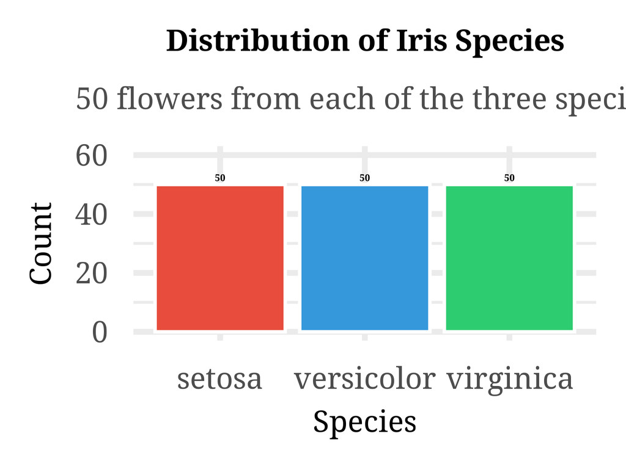

```r
# Count flowers per species
ggplot(iris, aes(x = Species, fill = Species)) +
  geom_bar(color = "white", linewidth = 1.5) +
  scale_fill_manual(values = iris_colors) +
  geom_text(
    stat = "count", aes(label = after_stat(count)),
    vjust = -0.5, size = 6, fontface = "bold"
  ) +
  labs(
    title = "Distribution of Iris Species",
    subtitle = "50 flowers from each of the three species",
    x = "Species",
    y = "Count"
  ) +
  theme(legend.position = "none") +
  ylim(0, 60)
```

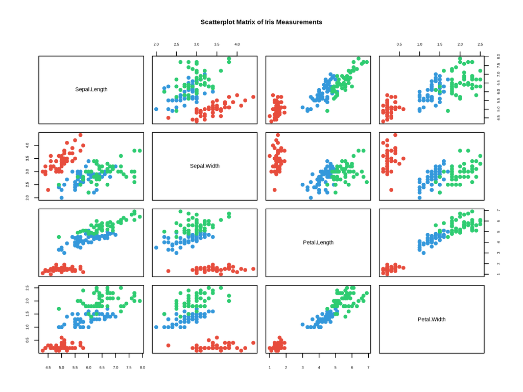

```r
# Create a scatterplot matrix to see all relationships
pairs(iris[, 1:4],
  col = iris_colors[iris$Species],
  pch = 19,
  main = "Scatterplot Matrix of Iris Measurements",
  cex.labels = 1.5
)
```

# Part 1: Simple Linear Regression

## What is Simple Linear Regression?

**Simple Linear Regression (SLR)** is the simplest form of regression. It models the relationship between **two continuous variables** using a straight line.

### The Mathematical Model

$$Y = \beta_0 + \beta_1 X +
\varepsilon$$

Where: - $Y$ = Dependent variable (response) - $X$ = Independent variable (predictor) - $\beta_0$ = Intercept (value of Y when X = 0) - $\beta_1$ = Slope (change in Y for a one-unit change in X) - $\varepsilon$ = Error term (random noise)

**The Goal**: Find the “best-fit” line that minimizes the sum of squared errors (differences between observed and predicted values). This is called the **Least Squares Method**.

### Assumptions of Linear Regression

1. **Linearity**: The relationship between X and Y is linear
2. **Independence**: Observations are independent of each other
3. **Homoscedasticity**: Constant variance of errors
4. **Normality**: Errors are normally distributed
5. **No multicollinearity**: (For multiple regression) Predictors are not highly correlated

## Example: Predicting Petal Length from Sepal Length

Let’s predict **Petal.Length** (Y) using **Sepal.Length** (X).

```r
# Fit a simple linear regression model
model_slr <- lm(Petal.Length ~ Sepal.Length, data = iris)

# View the model summary
summary(model_slr)
```

```
##
## Call:
## lm(formula = Petal.Length ~ Sepal.Length, data = iris)
##
## Residuals:
##      Min       1Q   Median       3Q      Max
## -2.47747 -0.59072 -0.00668  0.60484  2.49512
##
## Coefficients:
##              Estimate Std. Error t value Pr(>|t|)
## (Intercept)  -7.10144    0.50666  -14.02   <2e-16 ***
## Sepal.Length  1.85843    0.08586   21.65   <2e-16 ***
## ---
## Signif. codes:  0 '***' 0.001 '**' 0.01 '*' 0.05 '.' 0.1 ' ' 1
##
## Residual standard error: 0.8678 on 148 degrees of freedom
## Multiple R-squared:   0.76,  Adjusted R-squared:  0.7583
## F-statistic: 468.6 on 1 and 148 DF,  p-value: < 2.2e-16
```

### Interpreting the Output

The output shows several important pieces of information:

- **Coefficients**: The estimated $\beta_0$ (intercept) and $\beta_1$ (slope)
- **R-squared**: Proportion of variance in Y explained by X
- **p-values**: Statistical significance of coefficients
- **Residual standard error**: Typical size of prediction errors

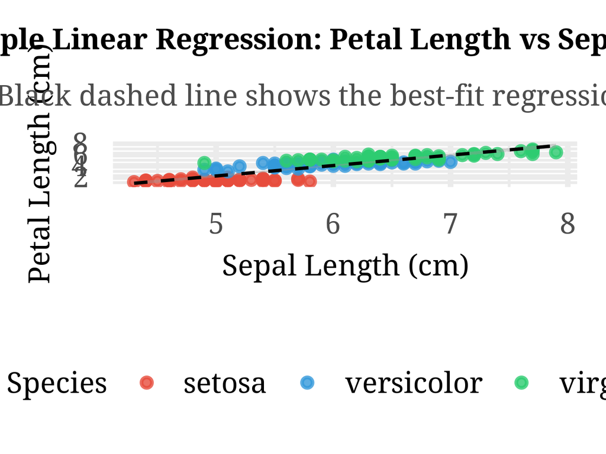

```r
# Visualize the regression line
ggplot(iris, aes(x = Sepal.Length, y = Petal.Length)) +
  geom_point(aes(color = Species), size = 3, alpha = 0.8) +
  geom_smooth(
    method = "lm", se = TRUE, color = "black",
    linetype = "dashed", linewidth = 1.5
  ) +
  scale_color_manual(values = iris_colors) +
  labs(
    title = "Simple Linear Regression: Petal Length vs Sepal Length",
    subtitle = "Black dashed line shows the best-fit regression line",
    x = "Sepal Length (cm)",
    y = "Petal Length (cm)"
  )
```

**Interpretation**: For every 1 cm increase in Sepal Length, Petal Length increases by approximately 1.86 cm (the slope coefficient). The R-squared value tells us what proportion of variation in Petal Length is explained by Sepal Length.

## Checking Model Assumptions

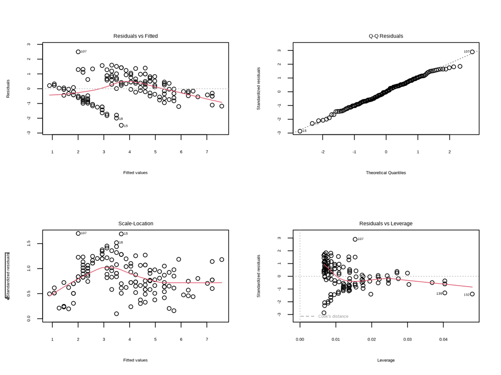

```r
# Create diagnostic plots to check assumptions
par(mfrow = c(2, 2))
plot(model_slr)
```

```r
par(mfrow = c(1, 1))
```

### Understanding Diagnostic Plots

1. **Residuals vs Fitted**: Should show no pattern (random scatter around 0)
2. **Normal Q-Q**: Points should fall along the diagonal line
3. **Scale-Location**: Should show constant variance (horizontal line)
4. **Residuals vs Leverage**: Identifies influential points

# Part 2: Multiple Linear Regression

## What is Multiple Linear Regression?

**Multiple Linear Regression (MLR)** extends simple linear regression by using **two or more predictors** to model the response variable.

### The Mathematical Model

$$Y = \beta_0 + \beta_1 X_1 + \beta_2 X_2
+ \cdots + \beta_p X_p + \varepsilon$$

Where: - $X_1, X_2, \ldots, X_p$ are the predictor variables - $\beta_1, \beta_2, \ldots, \beta_p$ are the partial regression coefficients

## Example: Predicting Petal Length from All Other Measurements

```r
# Fit multiple linear regression
model_mlr <- lm(Petal.Length ~ Sepal.Length + Sepal.Width + Petal.Width,
  data = iris
)

# View summary
summary(model_mlr)
```

```
##
## Call:
## lm(formula = Petal.Length ~ Sepal.Length + Sepal.Width + Petal.Width,
##     data = iris)
##
## Residuals:
##      Min       1Q   Median       3Q      Max
## -0.99333 -0.17656 -0.01004  0.18558  1.06909
##
## Coefficients:
##              Estimate Std. Error t value Pr(>|t|)
## (Intercept)  -0.26271    0.29741  -0.883    0.379
## Sepal.Length  0.72914    0.05832  12.502   <2e-16 ***
## Sepal.Width  -0.64601    0.06850  -9.431   <2e-16 ***
## Petal.Width   1.44679    0.06761  21.399   <2e-16 ***
## ---
## Signif. codes:  0 '***' 0.001 '**' 0.01 '*' 0.05 '.' 0.1 ' ' 1
##
## Residual standard error: 0.319 on 146 degrees of freedom
## Multiple R-squared:  0.968,  Adjusted R-squared:  0.9674
## F-statistic:  1473 on 3 and 146 DF,  p-value: < 2.2e-16
```

### Interpreting Multiple Regression Coefficients

In multiple regression, each coefficient represents the **change in Y for a one-unit change in that predictor, holding all other predictors constant**. This is why they’re called **partial regression coefficients**.

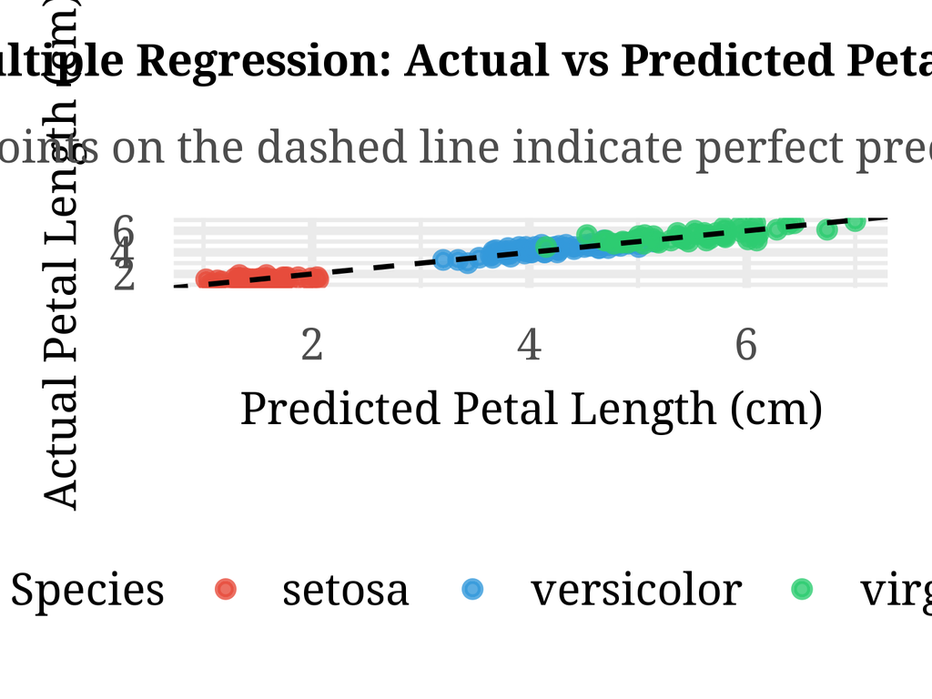

```r
# Visualize actual vs predicted values
iris$predicted_mlr <- predict(model_mlr)

ggplot(iris, aes(x = predicted_mlr, y = Petal.Length)) +
  geom_point(aes(color = Species), size = 3, alpha = 0.8) +
  geom_abline(
    intercept = 0, slope = 1, color = "black",
    linetype = "dashed", linewidth = 1.5
  ) +
  scale_color_manual(values = iris_colors) +
  labs(
    title = "Multiple Regression: Actual vs Predicted Petal Length",
    subtitle = "Points on the dashed line indicate perfect predictions",
    x = "Predicted Petal Length (cm)",
    y = "Actual Petal Length (cm)"
  )
```

## Model Comparison: SLR vs MLR

```r
# Compare R-squared values
cat(
  "Simple Linear Regression R-squared:",
  round(summary(model_slr)$r.squared, 4), "\n"
)
```

```
## Simple Linear Regression R-squared: 0.76
```

```r
cat(
  "Multiple Linear Regression R-squared:",
  round(summary(model_mlr)$r.squared, 4), "\n"
)
```

```
## Multiple Linear Regression R-squared: 0.968
```

**Key Insight**: Multiple regression typically has higher R-squared because adding more predictors always improves fit. However, we should use **Adjusted R-squared** for fair comparison, as it penalizes unnecessary predictors.

# Part 3: Polynomial Regression

## What is Polynomial Regression?

Sometimes relationships are not linear. **Polynomial regression** models curved relationships by including polynomial terms.

$$Y = \beta_0 + \beta_1 X + \beta_2 X^2 +
\beta_3 X^3 + \cdots + \varepsilon$$

```r
# Fit polynomial regression (degree 2)
model_poly <- lm(Petal.Length ~ Sepal.Length + I(Sepal.Length^2), data = iris)

# Compare with linear model
summary(model_poly)
```

```
##
## Call:
## lm(formula = Petal.Length ~ Sepal.Length + I(Sepal.Length^2),
##     data = iris)
##
## Residuals:
##     Min      1Q  Median      3Q     Max
## -2.6751 -0.5138  0.1218  0.5356  2.6287
##
## Coefficients:
##                    Estimate Std. Error t value Pr(>|t|)
## (Intercept)       -17.44671    3.08770  -5.650 8.04e-08 ***
## Sepal.Length        5.39216    1.04465   5.162 7.81e-07 ***
## I(Sepal.Length^2)  -0.29586    0.08719  -3.393 0.000887 ***
## ---
## Signif. codes:  0 '***' 0.001 '**' 0.01 '*' 0.05 '.' 0.1 ' ' 1
##
## Residual standard error: 0.8385 on 147 degrees of freedom
## Multiple R-squared:  0.7774, Adjusted R-squared:  0.7744
## F-statistic: 256.7 on 2 and 147 DF,  p-value: < 2.2e-16
```

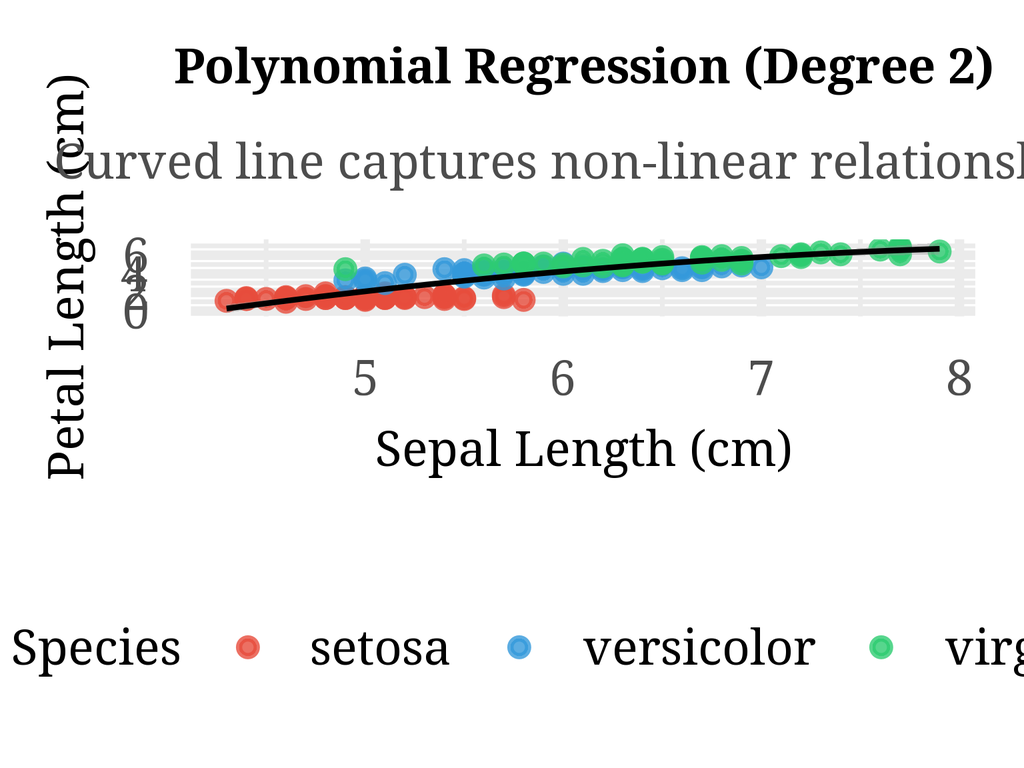

```r
# Visualize polynomial fit
ggplot(iris, aes(x = Sepal.Length, y = Petal.Length)) +
  geom_point(aes(color = Species), size = 3, alpha = 0.8) +
  geom_smooth(
    method = "lm", formula = y ~ poly(x, 2),
    color = "black", se = TRUE, linewidth = 1.5
  ) +
  scale_color_manual(values = iris_colors) +
  labs(
    title = "Polynomial Regression (Degree 2)",
    subtitle = "Curved line captures non-linear relationships",
    x = "Sepal Length (cm)",
    y = "Petal Length (cm)"
  )
```

# Part 4: Logistic Regression

## What is Logistic Regression?

**Logistic regression** is used when the response variable is **categorical** (usually binary). Instead of predicting a continuous value, we predict the **probability** of belonging to a category.

### The Logistic Function

$$P(Y = 1) = \frac{1}{1 + e^{-(\beta_0 +
\beta_1 X_1 + \cdots + \beta_p X_p)}}$$

The logistic function ensures predicted probabilities are between 0 and 1.

## Example: Classifying Setosa vs Others

```r
# Create binary response: Is it setosa?
iris$is_setosa <- ifelse(iris$Species == "setosa", 1, 0)

# Fit logistic regression
model_logit <- glm(
  is_setosa ~ Sepal.Length + Sepal.Width +
    Petal.Length + Petal.Width,
  data = iris, family = binomial
)

# View summary
summary(model_logit)
```

```
##
## Call:
## glm(formula = is_setosa ~ Sepal.Length + Sepal.Width + Petal.Length +
##     Petal.Width, family = binomial, data = iris)
##
## Coefficients:
##                Estimate Std. Error z value Pr(>|z|)
## (Intercept)     -16.946 457457.097       0        1
## Sepal.Length     11.759 130504.042       0        1
## Sepal.Width       7.842  59415.385       0        1
## Petal.Length    -20.088 107724.594       0        1
## Petal.Width     -21.608 154350.616       0        1
##
## (Dispersion parameter for binomial family taken to be 1)
##
##     Null deviance: 1.9095e+02  on 149  degrees of freedom
## Residual deviance: 3.2940e-09  on 145  degrees of freedom
## AIC: 10
##
## Number of Fisher Scoring iterations: 25
```

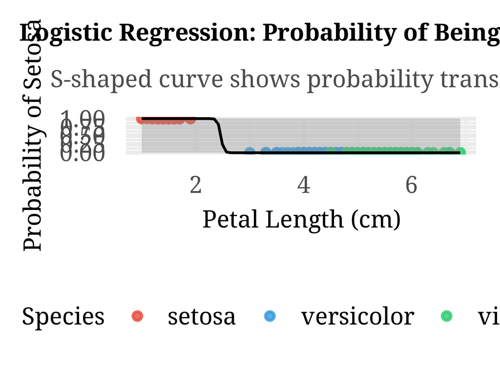

```r
# Predict probabilities
iris$prob_setosa <- predict(model_logit, type = "response")

# Visualize
ggplot(iris, aes(x = Petal.Length, y = prob_setosa)) +
  geom_point(aes(color = Species), size = 3, alpha = 0.8) +
  geom_smooth(
    method = "glm", method.args = list(family = binomial),
    color = "black", se = TRUE, linewidth = 1.5
  ) +
  scale_color_manual(values = iris_colors) +
  labs(
    title = "Logistic Regression: Probability of Being Setosa",
    subtitle = "S-shaped curve shows probability transition",
    x = "Petal Length (cm)",
    y = "Probability of Setosa"
  )
```

# Part 5: Linear Discriminant Analysis (LDA)

## What is LDA?

**Linear Discriminant Analysis (LDA)** is both a **dimensionality reduction** technique and a **classification** method. Developed by Fisher in 1936 (yes, the same Fisher who gave us the iris dataset!), LDA finds linear combinations of features that best separate classes.

### How Does LDA Work?

LDA makes three key assumptions: 1. **Normality**: Each class follows a multivariate normal distribution 2. **Equal covariance matrices**: All classes share the same covariance structure 3. **Independence**: Observations are independent

The algorithm works in two steps:

1. **Find discriminant axes**: Project data onto directions that maximize between-class variance while minimizing within-class variance
2. **Classify**: Assign new observations to the class with the closest mean (in discriminant space)

### The Mathematics Behind LDA

LDA seeks to find a projection vector **w** that maximizes:

$$J(w) = \frac{w^T S_B w}{w^T S_W
w}$$

Where: - $S_B$ = Between-class scatter matrix (measures separation between classes) - $S_W$ = Within-class scatter matrix (measures spread within each class)

**Intuition**: LDA finds the “best viewing angle” to separate the species. Imagine rotating a 3D scatter plot until the three species are most clearly separated – that’s what LDA does mathematically.

## Performing LDA on Iris Data

```r
# Perform LDA
model_lda <- lda(Species ~ Sepal.Length + Sepal.Width + Petal.Length + Petal.Width, data = iris)
# View the model
model_lda
```

```
## Call:
## lda(Species ~ Sepal.Length + Sepal.Width + Petal.Length + Petal.Width,
##     data = iris)
##
## Prior probabilities of groups:
##     setosa versicolor  virginica
##  0.3333333  0.3333333  0.3333333
##
## Group means:
##            Sepal.Length Sepal.Width Petal.Length Petal.Width
## setosa            5.006       3.428        1.462       0.246
## versicolor        5.936       2.770        4.260       1.326
## virginica         6.588       2.974        5.552       2.026
##
## Coefficients of linear discriminants:
##                     LD1         LD2
## Sepal.Length  0.8293776 -0.02410215
## Sepal.Width   1.5344731 -2.16452123
## Petal.Length -2.2012117  0.93192121
## Petal.Width  -2.8104603 -2.83918785
##
## Proportion of trace:
##    LD1    LD2
## 0.9912 0.0088
```

### Understanding LDA Output

The output shows: - **Prior probabilities**: Proportion of each species in the data - **Group means**: Average measurements for each species - **Coefficients of linear discriminants**: Weights for each variable in creating the discriminant axes

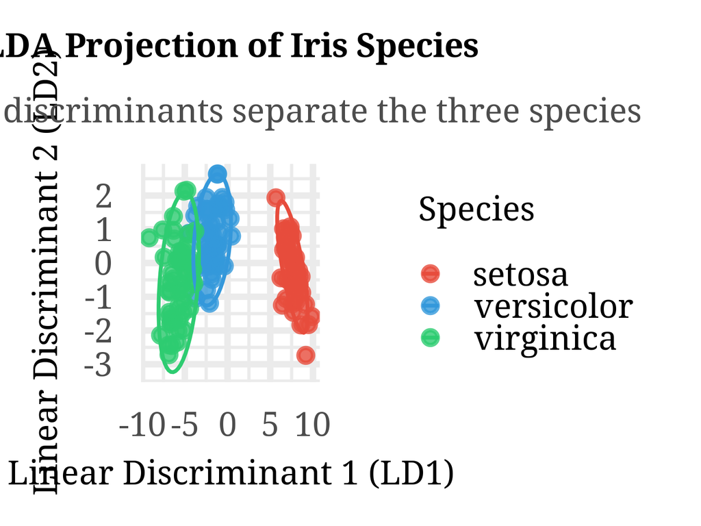

```r
# Predict LDA scores
lda_scores <- predict(model_lda)$x

# Create a data frame for plotting
lda_df <- data.frame(
  LD1 = lda_scores[, 1],
  LD2 = lda_scores[, 2],
  Species = iris$Species
)

# Plot LDA projection
ggplot(lda_df, aes(x = LD1, y = LD2, color = Species)) +
  geom_point(size = 4, alpha = 0.8) +
  stat_ellipse(level = 0.95, linewidth = 1.5) +
  scale_color_manual(values = iris_colors) +
  labs(
    title = "LDA Projection of Iris Species",
    subtitle = "Two linear discriminants separate the three species",
    x = "Linear Discriminant 1 (LD1)",
    y = "Linear Discriminant 2 (LD2)"
  ) +
  theme(legend.position = "right")
```

**Amazing Result**: Notice how well-separated the species are in LDA space! Even though we started with 4 dimensions, just 2 discriminant axes capture most of the class separation.

## LDA Classification Performance

```r
# Predict species
lda_pred <- predict(model_lda)$class

# Confusion matrix
confusion_lda <- table(Predicted = lda_pred, Actual = iris$Species)
print(confusion_lda)
```

```
##             Actual
## Predicted    setosa versicolor virginica
##   setosa         50          0         0
##   versicolor      0         48         1
##   virginica       0          2        49
```

```r
# Calculate accuracy
accuracy_lda <- sum(diag(confusion_lda)) / sum(confusion_lda)
cat("\nLDA Classification Accuracy:", round(accuracy_lda * 100, 2), "%\n")
```

```
##
## LDA Classification Accuracy: 98 %
```

### Visualizing the Confusion Matrix

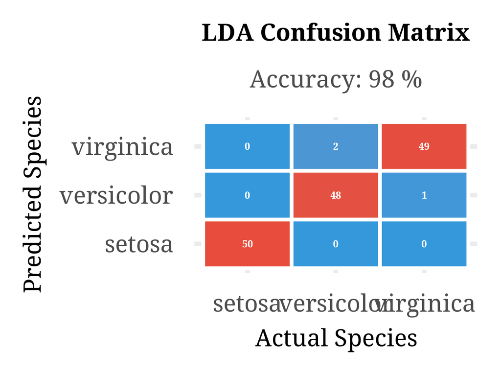

```r
# Convert confusion matrix to data frame
confusion_df <- as.data.frame(confusion_lda)

ggplot(confusion_df, aes(x = Actual, y = Predicted, fill = Freq)) +
  geom_tile(color = "white", linewidth = 2) +
  geom_text(aes(label = Freq), size = 8, fontface = "bold", color = "white") +
  scale_fill_gradient(low = "#3498DB", high = "#E74C3C") +
  labs(
    title = "LDA Confusion Matrix",
    subtitle = paste("Accuracy:", round(accuracy_lda * 100, 2), "%"),
    x = "Actual Species",
    y = "Predicted Species"
  ) +
  theme(legend.position = "none")
```

# Part 6: Other Regression Techniques

## Ridge Regression (L2 Regularization)

**Ridge regression** adds a penalty term to prevent overfitting when predictors are highly correlated.

$$\text{Minimize: } \sum_{i=1}^{n}(y_i -
\hat{y}_i)^2 + \lambda \sum_{j=1}^{p} \beta_j^2$$

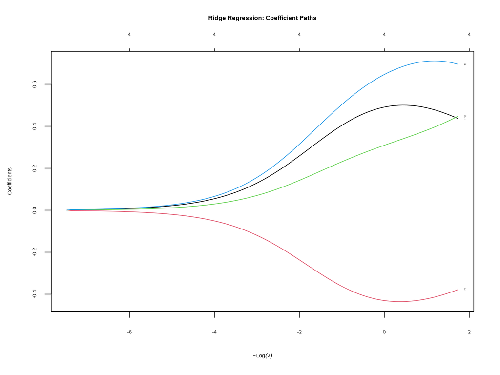

```r
# Ridge regression using glmnet
library(glmnet)

# Prepare data
x <- as.matrix(iris[, 1:4])
y <- iris$Petal.Length

# Fit ridge regression
model_ridge <- glmnet(x, y, alpha = 0)

# Plot coefficient paths
plot(model_ridge, xvar = "lambda", label = TRUE)
title("Ridge Regression: Coefficient Paths", line = 2.5)
```

## Lasso Regression (L1 Regularization)

**Lasso** (Least Absolute Shrinkage and Selection Operator) can shrink some coefficients to exactly zero, performing variable selection.

$$\text{Minimize: } \sum_{i=1}^{n}(y_i -
\hat{y}_i)^2 + \lambda \sum_{j=1}^{p} |\beta_j|$$

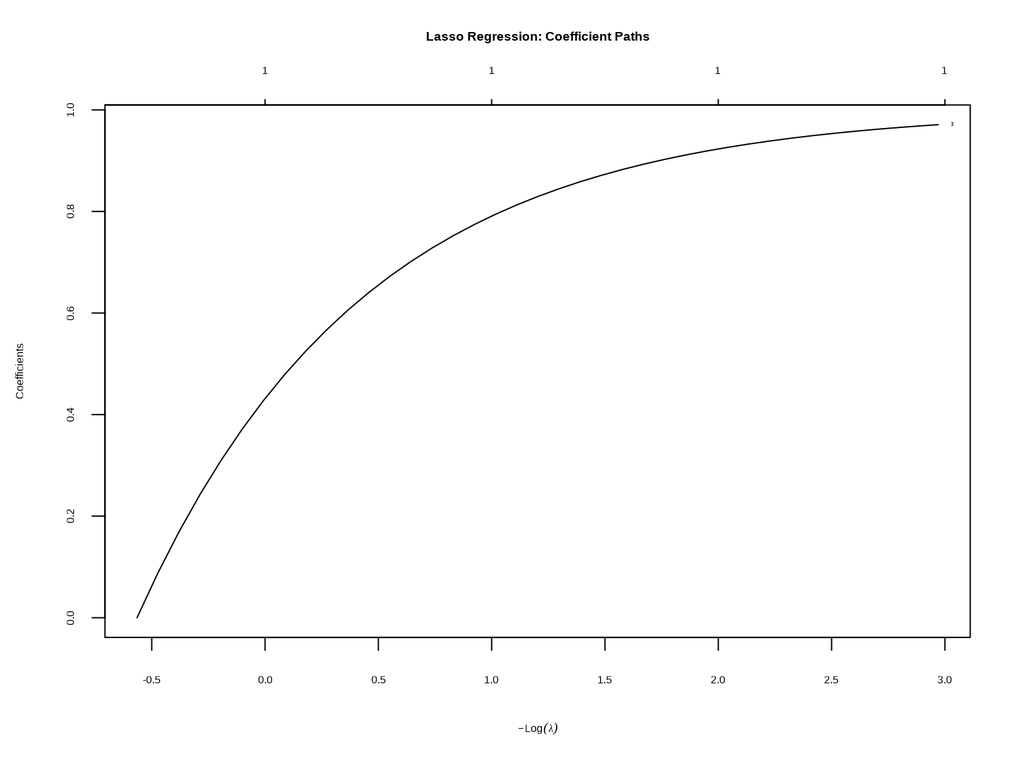

```r
# Fit lasso regression
model_lasso <- glmnet(x, y, alpha = 1)

# Plot coefficient paths
plot(model_lasso, xvar = "lambda", label = TRUE)
title("Lasso Regression: Coefficient Paths", line = 2.5)
```

## Quantile Regression

**Quantile regression** estimates the conditional median or other quantiles of the response variable, rather than the mean.

```r
library(quantreg)

# Fit quantile regression for median (0.5)
model_quant <- rq(Petal.Length ~ Sepal.Length, data = iris, tau = 0.5)

# Compare with linear regression
summary(model_quant)
```

```
##
## Call: rq(formula = Petal.Length ~ Sepal.Length, tau = 0.5, data = iris)
##
## tau: [1] 0.5
##
## Coefficients:
##              coefficients lower bd upper bd
## (Intercept)  -6.86364     -9.36601 -6.24413
## Sepal.Length  1.81818      1.70554  2.13286
```

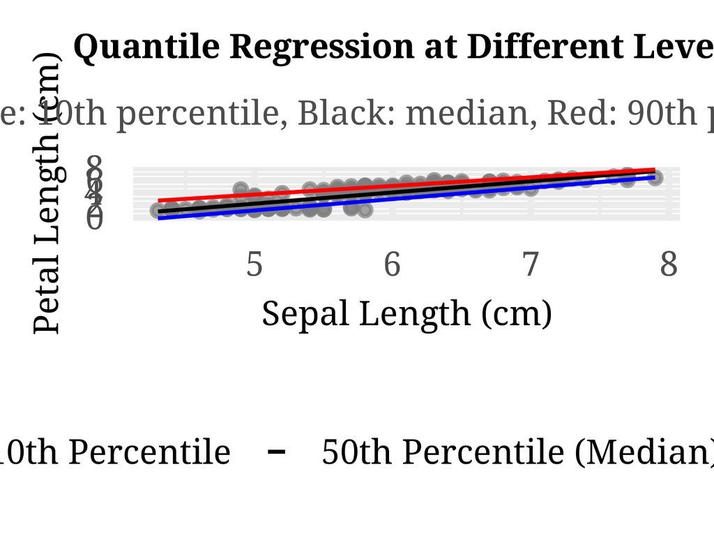

```r
library(ggplot2)
library(quantreg)

# Visualize multiple quantile regressions with distinct colors
ggplot(iris, aes(x = Sepal.Length, y = Petal.Length)) +
  geom_point(aes(color = Species), size = 3, alpha = 0.7) +
  scale_color_manual(values = iris_colors) +
  # Use ggnewscale or map quantiles inside aes() to separate scale mappings
  geom_quantile(
    aes(color = factor(after_stat(quantile))),
    quantiles = c(0.1, 0.5, 0.9),
    linewidth = 1.5
  ) +
  scale_color_manual(
    values = c("0.1" = "blue", "0.5" = "black", "0.9" = "red"),
    labels = c("10th Percentile", "50th Percentile (Median)", "90th Percentile"),
    name = "Quantile"
  ) +
  labs(
    title = "Quantile Regression at Different Levels",
    subtitle = "Blue: 10th percentile, Black: median, Red: 90th percentile",
    x = "Sepal Length (cm)",
    y = "Petal Length (cm)"
  )
```

# Part 7: Comparing All Methods

## Summary Table

| Method | Type | Response Variable | Key Feature | Best Use Case |
| --- | --- | --- | --- | --- |
| **Simple Linear** | Regression | Continuous | One predictor | Basic relationships |
| **Multiple Linear** | Regression | Continuous | Multiple predictors | Complex relationships |
| **Polynomial** | Regression | Continuous | Curved relationships | Non-linear patterns |
| **Logistic** | Classification | Binary/Categorical | Probability estimation | Binary outcomes |
| **LDA** | Classification | Categorical | Dimension reduction | Multi-class problems |
| **Ridge** | Regression | Continuous | L2 regularization | Correlated predictors |
| **Lasso** | Regression | Continuous | L1 regularization | Feature selection |
| **Quantile** | Regression | Continuous | Robust to outliers | Non-normal errors |

## Performance Comparison

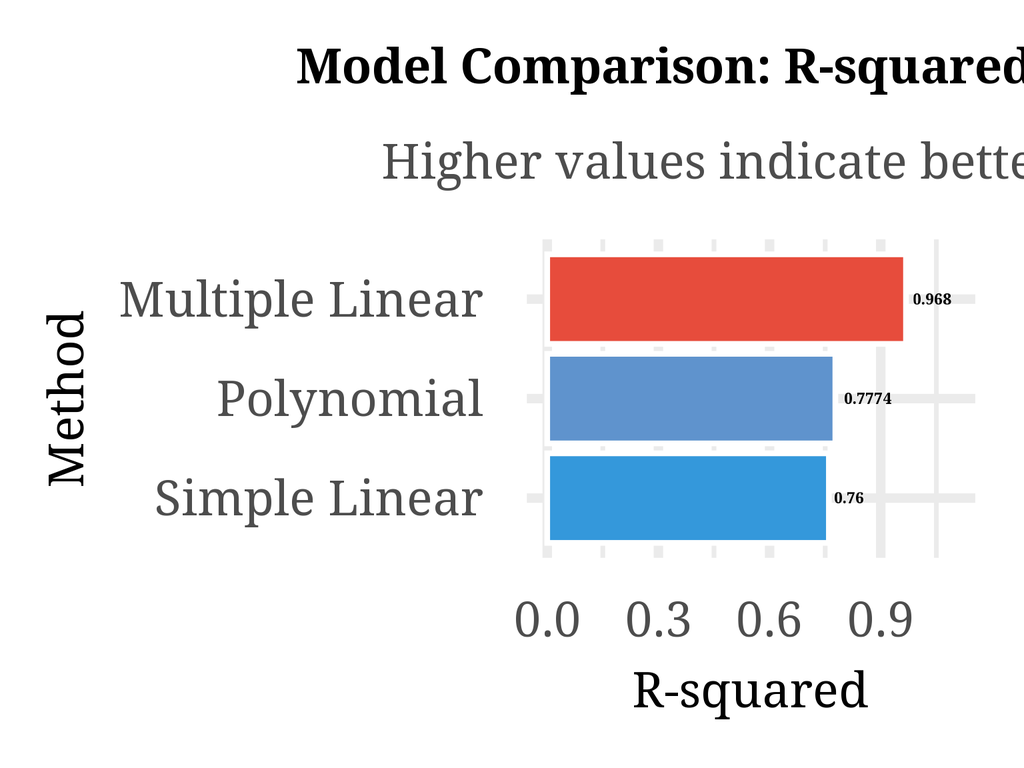

```r
# Create a comparison of R-squared values
methods <- c("Simple Linear", "Multiple Linear", "Polynomial")
r_squared <- c(
  summary(model_slr)$r.squared,
  summary(model_mlr)$r.squared,
  summary(model_poly)$r.squared
)

comparison_df <- data.frame(Method = methods, R_squared = r_squared)

ggplot(comparison_df, aes(x = reorder(Method, R_squared), y = R_squared, fill = R_squared)) +
  geom_col(color = "white", linewidth = 1.5) +
  geom_text(aes(label = round(R_squared, 4)), hjust = -0.2, size = 6, fontface = "bold") +
  scale_fill_gradient(low = "#3498DB", high = "#E74C3C") +
  coord_flip() +
  labs(
    title = "Model Comparison: R-squared Values",
    subtitle = "Higher values indicate better fit",
    x = "Method",
    y = "R-squared"
  ) +
  theme(legend.position = "none") +
  ylim(0, 1.1)
```

# Part 8: Practical Guidelines for Students

## When to Use Which Method?

**Common Mistake**: Students often use complex methods when simple ones would suffice. Always start with the simplest method and add complexity only when necessary.

### Decision Tree for Regression Methods

1. **Is your response variable continuous?**
   - Yes → Go to step 2
   - No (categorical) → Use **Logistic Regression** or **LDA**
2. **How many predictors do you have?**
   - One → **Simple Linear Regression**
   - Multiple → Go to step 3
3. **Is the relationship linear?**
   - Yes → **Multiple Linear Regression**
   - No → **Polynomial Regression** or transformation
4. **Are predictors highly correlated?**
   - Yes → **Ridge Regression**
   - Need feature selection → **Lasso Regression**
5. **Do you have outliers or non-normal errors?**
   - Yes → **Quantile Regression** or robust methods

## Checking Model Assumptions in R

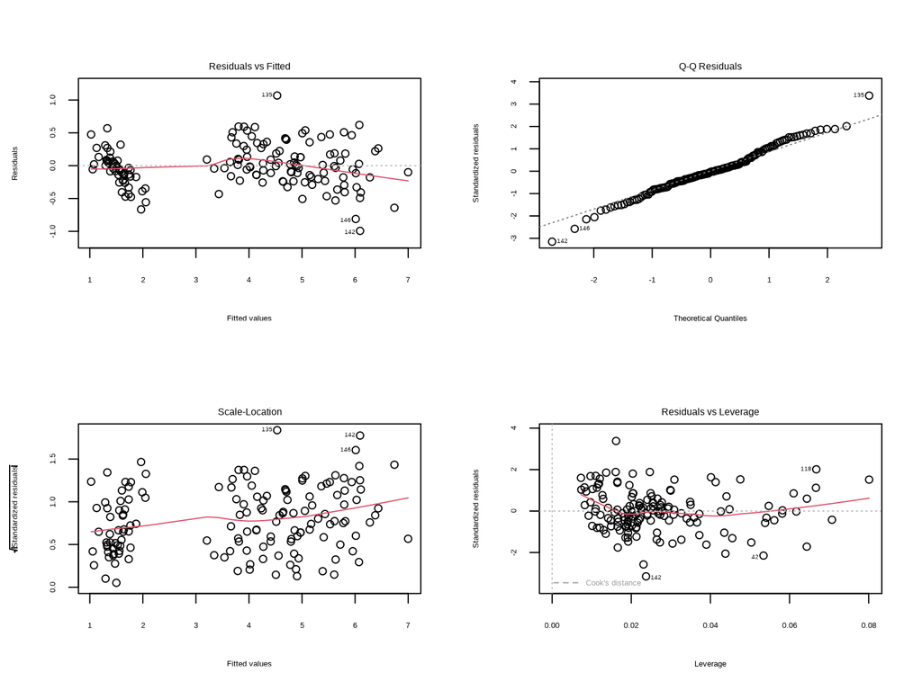

```r
# Function to check assumptions
check_assumptions <- function(model) {
  par(mfrow = c(2, 2))
  plot(model)
  par(mfrow = c(1, 1))
}

# Example usage
check_assumptions(model_mlr)
```

## Interpreting P-values

- **p < 0.001**: Extremely significant (***)
- **p < 0.01**: Very significant (**)
- **p < 0.05**: Significant (*)
- **p < 0.1**: Marginally significant (.)
- **p ≥ 0.1**: Not significant

**Remember**: Statistical significance does not imply practical significance. Always consider effect sizes and confidence intervals.

# Conclusion

## Key Takeaways

1. **Regression is about relationships**: It helps us understand how variables relate to each other and make predictions.
2. **Start simple**: Begin with simple linear regression and add complexity only when needed.
3. **Check assumptions**: Always verify that your data meets the assumptions of your chosen method.
4. **LDA is powerful**: For classification problems with continuous predictors, LDA often works remarkably well (as demonstrated by our 98% accuracy on iris data!).
5. **No single best method**: The “best” method depends on your data, your question, and your constraints.

## The Iris Dataset: A Perfect Teaching Tool

The iris dataset has taught generations of statisticians and data scientists because it: - Is small enough to understand completely - Has clear structure and patterns - Demonstrates both regression and classification - Shows the power of dimensionality reduction (LDA) - Connects to real-world biology

## Further Reading

- **“The Elements of Statistical Learning”** by Hastie, Tibshirani, and Friedman
- **“An Introduction to Statistical Learning”** by James, Witten, Hastie, and Tibshirani
- **“Applied Linear Statistical Models”** by Kutner, Nachtsheim, Neter, and Li

# Appendix: Complete Code Reference

```r
# ============================================================
# COMPLETE CODE FOR ALL METHODS
# ============================================================

# 1. Load libraries
library(ggplot2)
library(dplyr)
library(MASS)
library(glmnet)
library(quantreg)

# 2. Load data
data(iris)

# 3. Simple Linear Regression
model_slr <- lm(Petal.Length ~ Sepal.Length, data = iris)
summary(model_slr)

# 4. Multiple Linear Regression
model_mlr <- lm(Petal.Length ~ Sepal.Length + Sepal.Width + Petal.Width,
  data = iris
)
summary(model_mlr)

# 5. Polynomial Regression
model_poly <- lm(Petal.Length ~ Sepal.Length + I(Sepal.Length^2), data = iris)
summary(model_poly)

# 6. Logistic Regression
iris$is_setosa <- ifelse(iris$Species == "setosa", 1, 0)
model_logit <- glm(
  is_setosa ~ Sepal.Length + Sepal.Width +
    Petal.Length + Petal.Width,
  data = iris, family = binomial
)
summary(model_logit)

# 7. LDA
model_lda <- lda(Species ~ ., data = iris)
predictions <- predict(model_lda)$class
accuracy <- mean(predictions == iris$Species)
print(paste("LDA Accuracy:", round(accuracy * 100, 2), "%"))

# 8. Ridge Regression
x <- as.matrix(iris[, 1:4])
y <- iris$Petal.Length
model_ridge <- glmnet(x, y, alpha = 0)

# 9. Lasso Regression
model_lasso <- glmnet(x, y, alpha = 1)

# 10. Quantile Regression
model_quant <- rq(Petal.Length ~ Sepal.Length, data = iris, tau = 0.5)
summary(model_quant)
```

*Document prepared for undergraduate teaching in Civil Engineering and Data Science courses.*